# Titanic: Exploratory Data Analysis (EDA)

In this project, we will perform exploratory data analysis (EDA) on a titanic shipwreck and passenger survival data. You can find the dataset files used in the `Datasets` folder of this repository or download them directly from the source link.

Note: While exploring datasets for this assignment, I came across the Titanic dataset on Kaggle and found it really interesting. Kaggle features this dataset as a challenge, encouraging users to analyze passenger data from the Titanic shipwreck and predict survival probabilities. I never imagined working on something like this before, so this experience was truly exciting!

Source:  
`Titanic - Machine Learning from Disaster`  
https://www.kaggle.com/competitions/titanic

## Setting up the Environment

In the following steps, we will ensure that the project workspace is equipped with the necessary tools for data manipulation, visualization, and statistical analysis.

```python
from tqdm.auto import tqdm
import numpy as np
import pandas as pd
import matplotlib.pyplot as plt
from scipy import stats
import seaborn as sns
```

## Loading the Titanic Dataset

In this step, we are loading a dataset containing information about the passengers who were aboard the Titanic before it sank. The dataset includes details such as passenger ID, name, age, sex, and whether they survived the disaster. It also has information on family relations, including the number of siblings or spouses they were traveling with, as well as travel details such as ticket class, ticket number, fare, cabin, and port of embarkation. Understanding the structure of this dataset will help us perform meaningful exploratory data analysis later on.

```python
df_titanic = pd.read_csv('Datasets/train.csv')
```

## Data Familiarization

In this section, we will perform an initial exploration of the titanic dataset.

Our goals are to:

- **Identify data types:** Understand what kind of data each column holds (e.g., numerical, categorical).
- **Detect missing values:** Find any absent data points that might need handling.
- **Count entries:** Check the total number of rows to gauge the dataset's size.
- **Examine ranges:** Look at the minimum and maximum values for numerical columns.
- **Sample entries:** Display a few rows to visually inspect the data.
- **Review unique values:** For categorical variables, list unique values to understand the diversity in the data.

These steps are crucial to ensure data quality before moving forward with deeper analyses.

```python
df_titanic.head()
```

|  | PassengerId | Survived | Pclass | Name | Sex | Age | SibSp | Parch | Ticket | Fare | Cabin | Embarked |
| --- | --- | --- | --- | --- | --- | --- | --- | --- | --- | --- | --- | --- |
| 0 | 1 | 0 | 3 | Braund, Mr. Owen Harris | male | 22.0 | 1 | 0 | A/5 21171 | 7.2500 | NaN | S |
| 1 | 2 | 1 | 1 | Cumings, Mrs. John Bradley (Florence Briggs Th... | female | 38.0 | 1 | 0 | PC 17599 | 71.2833 | C85 | C |
| 2 | 3 | 1 | 3 | Heikkinen, Miss. Laina | female | 26.0 | 0 | 0 | STON/O2. 3101282 | 7.9250 | NaN | S |
| 3 | 4 | 1 | 1 | Futrelle, Mrs. Jacques Heath (Lily May Peel) | female | 35.0 | 1 | 0 | 113803 | 53.1000 | C123 | S |
| 4 | 5 | 0 | 3 | Allen, Mr. William Henry | male | 35.0 | 0 | 0 | 373450 | 8.0500 | NaN | S |

We are using `.info()` to get a concise summary of the dataset, including the data types and the number of non-null entries. This method is useful for quickly assessing the dataset's size and structure.

```python
df_titanic.info()
```

```
<class 'pandas.core.frame.DataFrame'>
RangeIndex: 891 entries, 0 to 890
Data columns (total 12 columns):
 #   Column       Non-Null Count  Dtype
---  ------       --------------  -----
 0   PassengerId  891 non-null    int64
 1   Survived     891 non-null    int64
 2   Pclass       891 non-null    int64
 3   Name         891 non-null    object
 4   Sex          891 non-null    object
 5   Age          714 non-null    float64
 6   SibSp        891 non-null    int64
 7   Parch        891 non-null    int64
 8   Ticket       891 non-null    object
 9   Fare         891 non-null    float64
 10  Cabin        204 non-null    object
 11  Embarked     889 non-null    object
dtypes: float64(2), int64(5), object(5)
memory usage: 83.7+ KB
```

### Columns in the Titanic Dataset

A brief description of what each column in the dataset means.

1. **PassengerId**: A unique ID assigned to each passenger in the dataset.
2. **Age**: The passenger's age in years.
3. **Fare**: The amount the passenger paid for their ticket (numeric).
4. **Survived**: Whether the passenger survived the disaster (1 = survived, 0 = did not survive).
5. **Pclass**: The socieconomic class of the passenger (1st, 2nd, or 3rd class).
6. **Sex**: The passenger's gender (Male or Female).
7. **SibSp**: Number of siblings or spouses the passenger was traveling with.
8. **Parch**: Number of parents or children the passenger was traveling with.
9. **Embarked**: The port where the passenger boarded (C = Cherbourg, Q = Queenstown, S = Southampton).
10. **Name**: The full name of the passenger.
11. **Ticket**: The alphanumeric ticket number assigned to the passenger.
12. **Cabin**: The cabin number where the passenger stayed (many missing values).

Let's check each column separately to better understand the dataset. We can start with the 'Age' column to see the ages of the people who were on the Titanic

```python
df_titanic['Age'].min(),df_titanic['Age'].max()
```

```
(0.42, 80.0)
```

```python
df_titanic['Fare'].min(),df_titanic['Fare'].max()
```

```
(0.0, 512.3292)
```

We can check what all data "Survived" columns has?

```python
df_titanic['Survived'].unique()
```

```
array([0, 1])
```

So for 'Survived' column:

- 0 = passenger didn't survive
- 1 = passenger survived

What about "Embarked" column?

```python
df_titanic['Embarked'].unique()
```

```
array(['S', 'C', 'Q', nan], dtype=object)
```

So, port of embarkation has 3 values: C = Cherbourg Q = Queenstown S = Southampton

What kind of values "Cabin" has?

```python
df_titanic['Cabin'].unique()
```

```
array([nan, 'C85', 'C123', 'E46', 'G6', 'C103', 'D56', 'A6',
       'C23 C25 C27', 'B78', 'D33', 'B30', 'C52', 'B28', 'C83', 'F33',
       'F G73', 'E31', 'A5', 'D10 D12', 'D26', 'C110', 'B58 B60', 'E101',
       'F E69', 'D47', 'B86', 'F2', 'C2', 'E33', 'B19', 'A7', 'C49', 'F4',
       'A32', 'B4', 'B80', 'A31', 'D36', 'D15', 'C93', 'C78', 'D35',
       'C87', 'B77', 'E67', 'B94', 'C125', 'C99', 'C118', 'D7', 'A19',
       'B49', 'D', 'C22 C26', 'C106', 'C65', 'E36', 'C54',
       'B57 B59 B63 B66', 'C7', 'E34', 'C32', 'B18', 'C124', 'C91', 'E40',
       'T', 'C128', 'D37', 'B35', 'E50', 'C82', 'B96 B98', 'E10', 'E44',
       'A34', 'C104', 'C111', 'C92', 'E38', 'D21', 'E12', 'E63', 'A14',
       'B37', 'C30', 'D20', 'B79', 'E25', 'D46', 'B73', 'C95', 'B38',
       'B39', 'B22', 'C86', 'C70', 'A16', 'C101', 'C68', 'A10', 'E68',
       'B41', 'A20', 'D19', 'D50', 'D9', 'A23', 'B50', 'A26', 'D48',
       'E58', 'C126', 'B71', 'B51 B53 B55', 'D49', 'B5', 'B20', 'F G63',
       'C62 C64', 'E24', 'C90', 'C45', 'E8', 'B101', 'D45', 'C46', 'D30',
       'E121', 'D11', 'E77', 'F38', 'B3', 'D6', 'B82 B84', 'D17', 'A36',
       'B102', 'B69', 'E49', 'C47', 'D28', 'E17', 'A24', 'C50', 'B42',
       'C148'], dtype=object)
```

Were there only males and females? or was there any other gender present?

```python
df_titanic['Sex'].unique()
```

```
array(['male', 'female'], dtype=object)
```

How about Pclass?

```python
df_titanic['Pclass'].unique()
```

```
array([3, 1, 2])
```

Som Pclass has these values: 1 - Upper Class 2 - Middle Class 3 - Lower Class

### Identifying Column Types

After examining each column in our dataset, we can categorize their data types in the following way:

- **Numerical** - PassengerId, Age, Fare
- **Categorical** - Survived, Pclass, Sex, SibSp, Parch, Embarked
- **Mixed** - Name, Ticket, Cabin

Let’s move on to performing some univariate analysis and focus on analyzing each feature in the dataset independently, at first.

## Univariate Analysis

We begin with a fundamental statistical analysis by examining individual variables independently. At this stage, we are not focusing on relationships between variables or cause-and-effect patterns; rather, we aim to understand the distribution, central tendency, and spread of each feature in the dataset.

### Statistical Summary of the Data

In this step, we generate a comprehensive summary table of the dataset that includes the count, mean, standard deviation, and various percentiles for each numeric column. This summary gives a quick, overall snapshot of the distribution and central tendencies within the data.

```python
df_titanic.describe().transpose()
```

|  | count | mean | std | min | 25% | 50% | 75% | max |
| --- | --- | --- | --- | --- | --- | --- | --- | --- |
| PassengerId | 891.0 | 446.000000 | 257.353842 | 1.00 | 223.5000 | 446.0000 | 668.5 | 891.0000 |
| Survived | 891.0 | 0.383838 | 0.486592 | 0.00 | 0.0000 | 0.0000 | 1.0 | 1.0000 |
| Pclass | 891.0 | 2.308642 | 0.836071 | 1.00 | 2.0000 | 3.0000 | 3.0 | 3.0000 |
| Age | 714.0 | 29.699118 | 14.526497 | 0.42 | 20.1250 | 28.0000 | 38.0 | 80.0000 |
| SibSp | 891.0 | 0.523008 | 1.102743 | 0.00 | 0.0000 | 0.0000 | 1.0 | 8.0000 |
| Parch | 891.0 | 0.381594 | 0.806057 | 0.00 | 0.0000 | 0.0000 | 0.0 | 6.0000 |
| Fare | 891.0 | 32.204208 | 49.693429 | 0.00 | 7.9104 | 14.4542 | 31.0 | 512.3292 |

### Descriptive Statistics & Distribution Analysis

Here, we compute key statistics to summarize the dataset:

- Mean & Median: Indicate central tendency, with the median being less affected by outliers.
- Standard Deviation: Measures data spread around the mean.
- Quantiles: Help understand distribution shape and detect skewness.

To complement this, we will visualize distributions using histograms, KDE plots, box plots, bar charts, and pie charts to uncover patterns like skewness, modality, and outliers.

Let's start by analyzing the distribution of 'Age', as it is an important numerical variable in our dataset.

#### Age

```python
df_titanic['Age'].describe()
```

```
count    714.000000
mean      29.699118
std       14.526497
min        0.420000
25%       20.125000
50%       28.000000
75%       38.000000
max       80.000000
Name: Age, dtype: float64
```

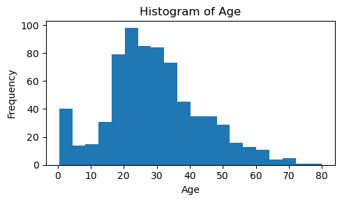

```python
fig = plt.figure(figsize=(5, 3))
plt.hist(df_titanic['Age'],bins=20)
plt.xlabel('Age')
plt.ylabel('Frequency')
plt.title('Histogram of Age')
plt.tight_layout()
plt.show()
```

It looks like there were many infants traveling on the Titanic and a lot of middle-aged people. There weren’t many people above 60 or 70.

Let's generate a KDE plot also for the 'Age' column to see if the distribution is normal or skewed in any way.

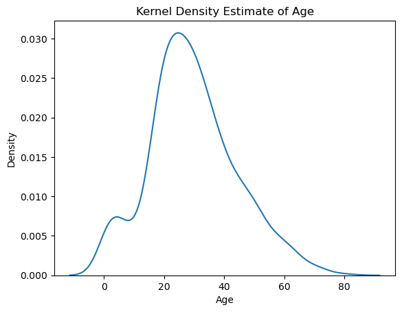

```python
sns.kdeplot(df_titanic['Age'])
plt.title('Kernel Density Estimate of Age')
plt.xlabel('Age')
plt.ylabel('Density')
plt.show()
```

```python
df_titanic['Age'].skew()
```

```
0.38910778230082704
```

It looks like we have almost a normal distribution for 'Age' column.

Let's generate a box plot as well to see if we have any outliers or not.

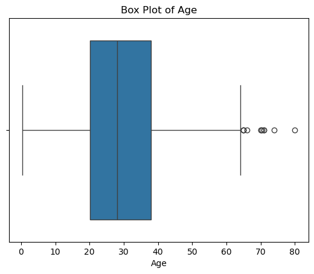

```python
sns.boxplot(x=df_titanic['Age'])
plt.title('Box Plot of Age')
plt.xlabel('Age')
plt.show()
```

It looks to me that people above the age of ~65 are being treated as outliers. Let's investigate more to see if those data points are valid or not.

```python
df_titanic[df_titanic['Age'] > 65]
```

|  | PassengerId | Survived | Pclass | Name | Sex | Age | SibSp | Parch | Ticket | Fare | Cabin | Embarked |
| --- | --- | --- | --- | --- | --- | --- | --- | --- | --- | --- | --- | --- |
| 33 | 34 | 0 | 2 | Wheadon, Mr. Edward H | male | 66.0 | 0 | 0 | C.A. 24579 | 10.5000 | NaN | S |
| 96 | 97 | 0 | 1 | Goldschmidt, Mr. George B | male | 71.0 | 0 | 0 | PC 17754 | 34.6542 | A5 | C |
| 116 | 117 | 0 | 3 | Connors, Mr. Patrick | male | 70.5 | 0 | 0 | 370369 | 7.7500 | NaN | Q |
| 493 | 494 | 0 | 1 | Artagaveytia, Mr. Ramon | male | 71.0 | 0 | 0 | PC 17609 | 49.5042 | NaN | C |
| 630 | 631 | 1 | 1 | Barkworth, Mr. Algernon Henry Wilson | male | 80.0 | 0 | 0 | 27042 | 30.0000 | A23 | S |
| 672 | 673 | 0 | 2 | Mitchell, Mr. Henry Michael | male | 70.0 | 0 | 0 | C.A. 24580 | 10.5000 | NaN | S |
| 745 | 746 | 0 | 1 | Crosby, Capt. Edward Gifford | male | 70.0 | 1 | 1 | WE/P 5735 | 71.0000 | B22 | S |
| 851 | 852 | 0 | 3 | Svensson, Mr. Johan | male | 74.0 | 0 | 0 | 347060 | 7.7750 | NaN | S |

It doesn't look like there's anything wrong with the data points here for 'Age' column. There are some people who had an older age range so we don't need to filter out any values here.

I did notice that the count of 'Age' was lower than some of the other columns when we used the describe query. Let's quickly check how many values are missing from the dataset.

```python
print(df_titanic['Age'].isnull().sum())
print((df_titanic['Age'].isnull().sum() / len(df_titanic)) * 100)
```

```
177
19.865319865319865
```

We have almost 20% of people in our dataset that we don't know the age for! Something to keep in mind!

Let's try to follow the same steps for another numerical column now - 'Fare'.

#### Fare

```python
df_titanic['Fare'].describe()
```

```
count    891.000000
mean      32.204208
std       49.693429
min        0.000000
25%        7.910400
50%       14.454200
75%       31.000000
max      512.329200
Name: Fare, dtype: float64
```

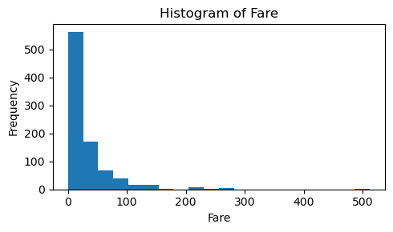

```python
fig = plt.figure(figsize=(5, 3))
plt.hist(df_titanic['Fare'],bins=20)
plt.xlabel('Fare')
plt.ylabel('Frequency')
plt.title('Histogram of Fare')
plt.tight_layout()
plt.show()
```

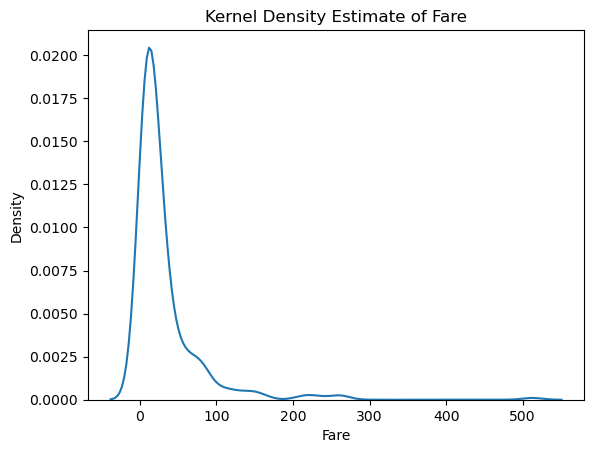

```python
sns.kdeplot(df_titanic['Fare'])
plt.title('Kernel Density Estimate of Fare')
plt.xlabel('Fare')
plt.ylabel('Density')
plt.show()
```

```python
df_titanic['Fare'].skew()
```

```
4.787316519674893
```

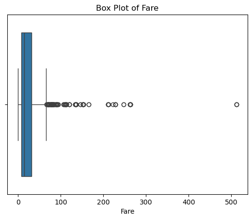

```python
sns.boxplot(x=df_titanic['Fare'])
plt.title('Box Plot of Fare')
plt.xlabel('Fare')
plt.show()
```

Lots of outliers. Let's see what's happening.

```python
df_titanic[df_titanic['Fare'] > 200]
```

|  | PassengerId | Survived | Pclass | Name | Sex | Age | SibSp | Parch | Ticket | Fare | Cabin | Embarked |
| --- | --- | --- | --- | --- | --- | --- | --- | --- | --- | --- | --- | --- |
| 27 | 28 | 0 | 1 | Fortune, Mr. Charles Alexander | male | 19.0 | 3 | 2 | 19950 | 263.0000 | C23 C25 C27 | S |
| 88 | 89 | 1 | 1 | Fortune, Miss. Mabel Helen | female | 23.0 | 3 | 2 | 19950 | 263.0000 | C23 C25 C27 | S |
| 118 | 119 | 0 | 1 | Baxter, Mr. Quigg Edmond | male | 24.0 | 0 | 1 | PC 17558 | 247.5208 | B58 B60 | C |
| 258 | 259 | 1 | 1 | Ward, Miss. Anna | female | 35.0 | 0 | 0 | PC 17755 | 512.3292 | NaN | C |
| 299 | 300 | 1 | 1 | Baxter, Mrs. James (Helene DeLaudeniere Chaput) | female | 50.0 | 0 | 1 | PC 17558 | 247.5208 | B58 B60 | C |
| 311 | 312 | 1 | 1 | Ryerson, Miss. Emily Borie | female | 18.0 | 2 | 2 | PC 17608 | 262.3750 | B57 B59 B63 B66 | C |
| 341 | 342 | 1 | 1 | Fortune, Miss. Alice Elizabeth | female | 24.0 | 3 | 2 | 19950 | 263.0000 | C23 C25 C27 | S |
| 377 | 378 | 0 | 1 | Widener, Mr. Harry Elkins | male | 27.0 | 0 | 2 | 113503 | 211.5000 | C82 | C |
| 380 | 381 | 1 | 1 | Bidois, Miss. Rosalie | female | 42.0 | 0 | 0 | PC 17757 | 227.5250 | NaN | C |
| 438 | 439 | 0 | 1 | Fortune, Mr. Mark | male | 64.0 | 1 | 4 | 19950 | 263.0000 | C23 C25 C27 | S |
| 527 | 528 | 0 | 1 | Farthing, Mr. John | male | NaN | 0 | 0 | PC 17483 | 221.7792 | C95 | S |
| 557 | 558 | 0 | 1 | Robbins, Mr. Victor | male | NaN | 0 | 0 | PC 17757 | 227.5250 | NaN | C |
| 679 | 680 | 1 | 1 | Cardeza, Mr. Thomas Drake Martinez | male | 36.0 | 0 | 1 | PC 17755 | 512.3292 | B51 B53 B55 | C |
| 689 | 690 | 1 | 1 | Madill, Miss. Georgette Alexandra | female | 15.0 | 0 | 1 | 24160 | 211.3375 | B5 | S |
| 700 | 701 | 1 | 1 | Astor, Mrs. John Jacob (Madeleine Talmadge Force) | female | 18.0 | 1 | 0 | PC 17757 | 227.5250 | C62 C64 | C |
| 716 | 717 | 1 | 1 | Endres, Miss. Caroline Louise | female | 38.0 | 0 | 0 | PC 17757 | 227.5250 | C45 | C |
| 730 | 731 | 1 | 1 | Allen, Miss. Elisabeth Walton | female | 29.0 | 0 | 0 | 24160 | 211.3375 | B5 | S |
| 737 | 738 | 1 | 1 | Lesurer, Mr. Gustave J | male | 35.0 | 0 | 0 | PC 17755 | 512.3292 | B101 | C |
| 742 | 743 | 1 | 1 | Ryerson, Miss. Susan Parker "Suzette" | female | 21.0 | 2 | 2 | PC 17608 | 262.3750 | B57 B59 B63 B66 | C |
| 779 | 780 | 1 | 1 | Robert, Mrs. Edward Scott (Elisabeth Walton Mc... | female | 43.0 | 0 | 1 | 24160 | 211.3375 | B3 | S |

Looks like there are multiple passenger tickets with same ticket number. Could be the fare for the entire family than just individual ticket fares.

```python
print(df_titanic['Fare'].isnull().sum())
```

```
0
```

We can now focus on data points that have categorical data types - starting with 'Survived' column.

#### Survived

```python
survival_counts = df_titanic['Survived'].value_counts()
print(survival_counts)
```

```
Survived
0    549
1    342
Name: count, dtype: int64
```

549 passengers died in the shipwreck while 342 survived.

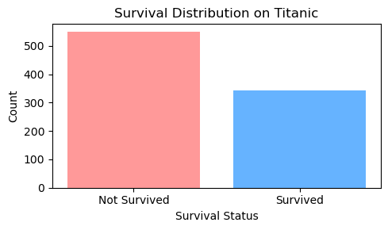

```python
plt.figure(figsize=(5, 3))
plt.bar(survival_counts.index, survival_counts.values, color=['#ff9999','#66b3ff'])
plt.xlabel('Survival Status')
plt.ylabel('Count')
plt.title('Survival Distribution on Titanic')
plt.xticks([0, 1], ['Not Survived', 'Survived'])
plt.tight_layout()
plt.show()
```

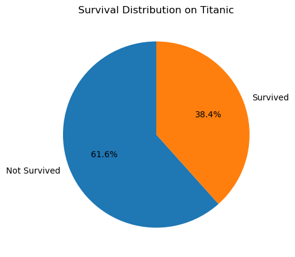

```python
plt.figure(figsize=(5, 5))
plt.pie(survival_counts, labels=['Not Survived', 'Survived'], autopct='%1.1f%%', startangle=90)
plt.title('Survival Distribution on Titanic')
plt.show()
```

Looks like more than half the passengers did not survive the shipreck!

```python
print(df_titanic['Survived'].isnull().sum())
```

```
0
```

Moving on the next categorical column - 'Pclass'

#### Pclass

```python
pclass_counts=df_titanic['Pclass'].value_counts()
print(pclass_counts)
```

```
Pclass
3    491
1    216
2    184
Name: count, dtype: int64
```

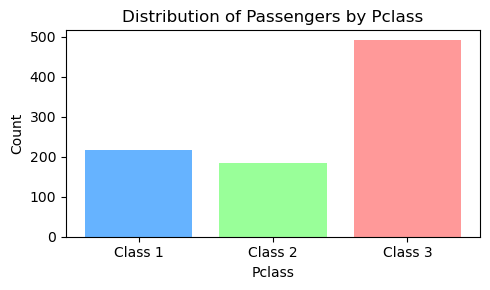

```python
plt.figure(figsize=(5, 3))
plt.bar(pclass_counts.index, pclass_counts.values, color=['#ff9999','#66b3ff', '#99ff99'])
plt.xlabel('Pclass')
plt.ylabel('Count')
plt.title('Distribution of Passengers by Pclass')
plt.xticks([1, 2, 3], ['Class 1', 'Class 2', 'Class 3'])
plt.tight_layout()
plt.show()
```

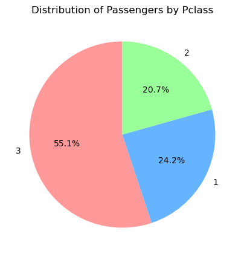

```python
plt.figure(figsize=(5, 5))
plt.pie(pclass_counts, labels=pclass_counts.index, autopct='%1.1f%%', startangle=90, colors=['#ff9999','#66b3ff','#99ff99'])
plt.title('Distribution of Passengers by Pclass')
plt.show()
```

Looks like a lot of passengers were travelling in Pclass 3 - which was the class with cheapest ticket fare. After that, more people were travelling in Pclass 1 compared to Pclass 2 - which seems a bit odd!

```python
print(df_titanic['Pclass'].isnull().sum())
```

```
0
```

Moving on the next categorical column - 'Sex'

#### Sex

```python
sex_counts = df_titanic['Sex'].value_counts()
print(sex_counts)
```

```
Sex
male      577
female    314
Name: count, dtype: int64
```

[figure not shown]

```python
plt.figure(figsize=(5, 3))
plt.bar(survival_counts.index, survival_counts.values, color=['#ff9999','#66b3ff'])
plt.xlabel('Sex')
plt.ylabel('Count')
plt.title('Gender Distribution on Titanic')
plt.xticks([0, 1], ['Male', 'Female'])
plt.tight_layout()
plt.show()
```

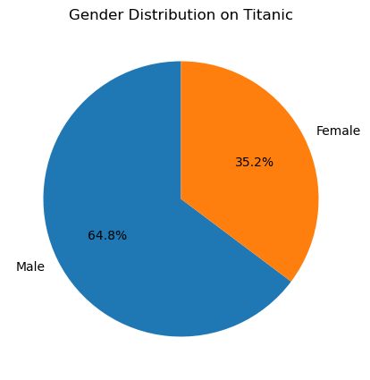

```python
plt.figure(figsize=(5, 5))
plt.pie(sex_counts, labels=['Male', 'Female'], autopct='%1.1f%%', startangle=90)
plt.title('Gender Distribution on Titanic')
plt.show()
```

Looks like more males were onboard the Titanic compared to female passengers.

```python
print(df_titanic['Sex'].isnull().sum())
```

```
0
```

Moving on to the next categorical columns - 'SibSp'

#### SibSp

```python
sibsp_counts=df_titanic['SibSp'].value_counts()
print(sibsp_counts)
```

```
SibSp
0    608
1    209
2     28
4     18
3     16
8      7
5      5
Name: count, dtype: int64
```

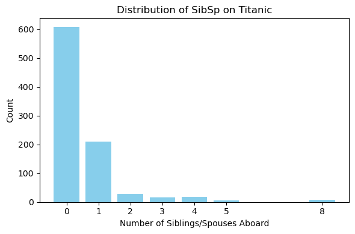

```python
plt.figure(figsize=(6, 4))
plt.bar(sibsp_counts.index, sibsp_counts.values, color='skyblue')
plt.xlabel('Number of Siblings/Spouses Aboard')
plt.ylabel('Count')
plt.title('Distribution of SibSp on Titanic')
plt.xticks(sibsp_counts.index)
plt.tight_layout()
plt.show()
```

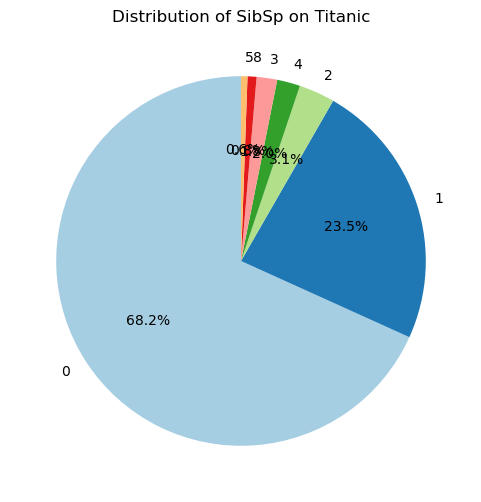

```python
plt.figure(figsize=(6, 6))
plt.pie(sibsp_counts, labels=sibsp_counts.index, autopct='%1.1f%%', startangle=90, colors=plt.cm.Paired.colors)
plt.title('Distribution of SibSp on Titanic')
plt.show()
```

Looks like a lot of passengers (around 69%) were travelling alone on the Titanic.

```python
print(df_titanic['SibSp'].isnull().sum())
```

```
0
```

Moving on the next categorical column - 'Parch'

#### Parch

```python
parch_counts=df_titanic['Parch'].value_counts()
print(parch_counts)
```

```
Parch
0    678
1    118
2     80
5      5
3      5
4      4
6      1
Name: count, dtype: int64
```

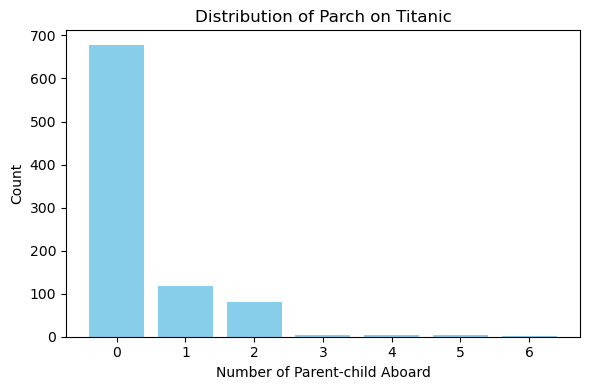

```python
plt.figure(figsize=(6, 4))
plt.bar(parch_counts.index, parch_counts.values, color='skyblue')
plt.xlabel('Number of Parent-child Aboard')
plt.ylabel('Count')
plt.title('Distribution of Parch on Titanic')
plt.xticks(parch_counts.index)
plt.tight_layout()
plt.show()
```

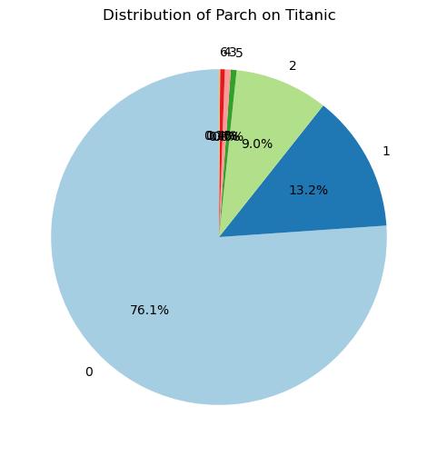

```python
plt.figure(figsize=(6, 6))
plt.pie(parch_counts, labels=parch_counts.index, autopct='%1.1f%%', startangle=90, colors=plt.cm.Paired.colors)
plt.title('Distribution of Parch on Titanic')
plt.show()
```

Looks like a lot of passengers (around 76%) were traveling alone on the Titanic.

```python
print(df_titanic['Parch'].isnull().sum())
```

```
0
```

Moving on the last categorical column - 'Embarked'

#### Embarked

```python
embarked_counts=df_titanic['Embarked'].value_counts()
print(embarked_counts)
```

```
Embarked
S    644
C    168
Q     77
Name: count, dtype: int64
```

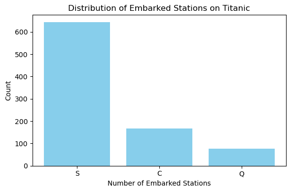

```python
plt.figure(figsize=(6, 4))
plt.bar(embarked_counts.index, embarked_counts.values, color='skyblue')
plt.xlabel('Number of Embarked Stations')
plt.ylabel('Count')
plt.title('Distribution of Embarked Stations on Titanic')
plt.xticks(embarked_counts.index)
plt.tight_layout()
plt.show()
```

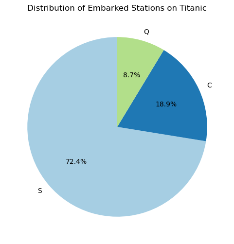

```python
plt.figure(figsize=(6, 6))
plt.pie(embarked_counts, labels=embarked_counts.index, autopct='%1.1f%%', startangle=90, colors=plt.cm.Paired.colors)
plt.title('Distribution of Embarked Stations on Titanic')
plt.show()
```

```python
print(df_titanic['Embarked'].isnull().sum())
```

```
2
```

### Insights from Univariate Analysis

In this section, we will summarize the findings of our univariate analysis and write down all the insights we have so far.

**Passenger ID**

- Don't think we need to do anything with this field - just a unique identifier.

**Age**

- Many infants traveling on the Titanic and a lot of middle-aged people. There weren’t many people above 60 or 70.
- It has (almost) normal distribution.
- 20% of the values are missing.
- There are some outliers above age of ~65, data looked valid though.

**Fare**

- More than half the passengers did not survive the shipwreck!
- No null values

**Pclass**

- Looks like a lot of passengers were traveling in Pclass 3 - which was the class with cheapest ticket fare.
- After that, more people were traveling in Pclass 1 compared to Pclass 2 - which seems a bit odd!
- No null values

**Sex**

- There were more males (~65%) on the ship than females.

**Sibsp**

- Looks like a lot of passengers (around 69%) were traveling alone on the Titanic.

**Parch**

- Looks like a lot of passengers (around 76%) were traveling alone on the Titanic.
- It also looks like we can create a family size column to make sense of the family together.

**Embarked**

- Most of the passengers embarked from the station S (Southampton - ~72%)
- 2 null values

**Columns I couldn't do anything with:**

- Name, ticket, cabin

## Bivariate Analysis

In this section, we examine the relationships between two different columns within the titanic dataset.

```python
df_titanic
```

|  | PassengerId | Survived | Pclass | Name | Sex | Age | SibSp | Parch | Ticket | Fare | Cabin | Embarked |
| --- | --- | --- | --- | --- | --- | --- | --- | --- | --- | --- | --- | --- |
| 0 | 1 | 0 | 3 | Braund, Mr. Owen Harris | male | 22.0 | 1 | 0 | A/5 21171 | 7.2500 | NaN | S |
| 1 | 2 | 1 | 1 | Cumings, Mrs. John Bradley (Florence Briggs Th... | female | 38.0 | 1 | 0 | PC 17599 | 71.2833 | C85 | C |
| 2 | 3 | 1 | 3 | Heikkinen, Miss. Laina | female | 26.0 | 0 | 0 | STON/O2. 3101282 | 7.9250 | NaN | S |
| 3 | 4 | 1 | 1 | Futrelle, Mrs. Jacques Heath (Lily May Peel) | female | 35.0 | 1 | 0 | 113803 | 53.1000 | C123 | S |
| 4 | 5 | 0 | 3 | Allen, Mr. William Henry | male | 35.0 | 0 | 0 | 373450 | 8.0500 | NaN | S |
| ... | ... | ... | ... | ... | ... | ... | ... | ... | ... | ... | ... | ... |
| 886 | 887 | 0 | 2 | Montvila, Rev. Juozas | male | 27.0 | 0 | 0 | 211536 | 13.0000 | NaN | S |
| 887 | 888 | 1 | 1 | Graham, Miss. Margaret Edith | female | 19.0 | 0 | 0 | 112053 | 30.0000 | B42 | S |
| 888 | 889 | 0 | 3 | Johnston, Miss. Catherine Helen "Carrie" | female | NaN | 1 | 2 | W./C. 6607 | 23.4500 | NaN | S |
| 889 | 890 | 1 | 1 | Behr, Mr. Karl Howell | male | 26.0 | 0 | 0 | 111369 | 30.0000 | C148 | C |
| 890 | 891 | 0 | 3 | Dooley, Mr. Patrick | male | 32.0 | 0 | 0 | 370376 | 7.7500 | NaN | Q |

891 rows × 12 columns

To begin with, we should focus on the 'Survived' column and it's relationship with other data points since we want to examine what passengers survived or not and based on what factors.

#### Survived Rate by Passenger Class

```python
df_titanic.groupby(['Pclass'],as_index=False)['Survived'].mean()
```

|  | Pclass | Survived |
| --- | --- | --- |
| 0 | 1 | 0.629630 |
| 1 | 2 | 0.472826 |
| 2 | 3 | 0.242363 |

We now know how many passengers survived or not based on their 'Pclass'.

Looks like 'Pclass' 3 was the most dangerous class - most amount of passengers died in that class. Safest class seems to 'Pclass' 1 with survival rate of 62%.

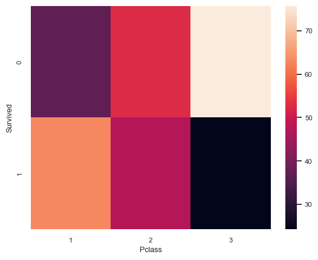

```python
sns.heatmap(pd.crosstab(df_titanic['Survived'],df_titanic['Pclass'], normalize='columns')*100) # Creating heatmap
```

#### Survival Rate by Gender

```python
df_titanic.groupby(['Sex'],as_index=False)['Survived'].mean()
```

|  | Sex | Survived |
| --- | --- | --- |
| 0 | female | 0.742038 |
| 1 | male | 0.188908 |

More female passengers survived compared to males.

#### Survival Rate by Port of Embarkation

```python
df_titanic.groupby(['Embarked'],as_index=False)['Survived'].mean()
```

|  | Embarked | Survived |
| --- | --- | --- |
| 0 | C | 0.553571 |
| 1 | Q | 0.389610 |
| 2 | S | 0.336957 |

Passengers who embarked from the last stop had survived more.

#### Survival Rate by Siblings

```python
df_titanic.groupby(['SibSp'],as_index=False)['Survived'].mean()
```

|  | SibSp | Survived |
| --- | --- | --- |
| 0 | 0 | 0.345395 |
| 1 | 1 | 0.535885 |
| 2 | 2 | 0.464286 |
| 3 | 3 | 0.250000 |
| 4 | 4 | 0.166667 |
| 5 | 5 | 0.000000 |
| 6 | 8 | 0.000000 |

Larger family groups didn't survive.

#### Survival Rate by Parch

```python
df_titanic.groupby(['Parch'],as_index=False)['Survived'].mean()
```

|  | Parch | Survived |
| --- | --- | --- |
| 0 | 0 | 0.343658 |
| 1 | 1 | 0.550847 |
| 2 | 2 | 0.500000 |
| 3 | 3 | 0.600000 |
| 4 | 4 | 0.000000 |
| 5 | 5 | 0.200000 |
| 6 | 6 | 0.000000 |

```python
df_titanic['Family_Size'] = df_titanic['SibSp'] + df_titanic['Parch'] + 1 # adding 1 for the passenger themselves.
```

```python
df_titanic.head()
```

[output not shown]

#### Survival Rate by Port of Family Size

```python
df_titanic.groupby(['Family_Size'],as_index=False)['Survived'].mean()
```

|  | Family_Size | Survived |
| --- | --- | --- |
| 0 | 1 | 0.303538 |
| 1 | 2 | 0.552795 |
| 2 | 3 | 0.578431 |
| 3 | 4 | 0.724138 |
| 4 | 5 | 0.200000 |
| 5 | 6 | 0.136364 |
| 6 | 7 | 0.333333 |
| 7 | 8 | 0.000000 |
| 8 | 11 | 0.000000 |

Small family sizes has higher survival rate.

Also, creating a family map to see who is alone and what family size people have.

```python
family_map = {
    1: 'Alone',
    2: 'Small', 3: 'Small', 4: 'Small',
    5: 'Medium', 6: 'Medium',
    7: 'Large', 8: 'Large', 9: 'Large', 10: 'Large', 11: 'Large'
}
df_titanic['Family_Size_Grouped'] = df_titanic['Family_Size'].map(family_map)
```

```python
df_titanic.head()
```

[output not shown]

#### Survival Rate by Port of Family Size Grouped

```python
df_titanic.groupby(['Family_Size_Grouped'],as_index=False)['Survived'].mean()
```

|  | Family_Size_Grouped | Survived |
| --- | --- | --- |
| 0 | Alone | 0.303538 |
| 1 | Large | 0.160000 |
| 2 | Medium | 0.162162 |
| 3 | Small | 0.578767 |

#### Survival Rate by Port of Age

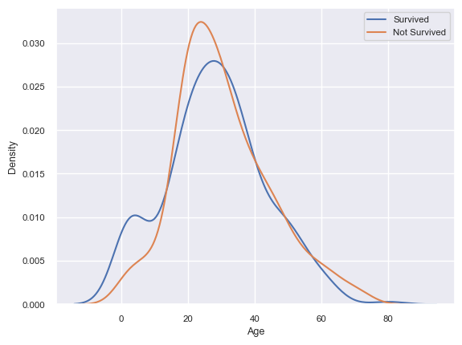

```python
sns.kdeplot(data=df_titanic[df_titanic['Survived'] == 1], x='Age', label='Survived')
sns.kdeplot(data=df_titanic[df_titanic['Survived'] == 0], x='Age', label='Not Survived')
plt.legend()
plt.show()
```

It looks like younger people survived more.

```python
df_titanic[df_titanic['Pclass'] == 1]['Age'].mean()
```

```
38.233440860215055
```

Most rich people were middle aged.

### Insights from Bivariate Analysis

- People in the first or second pclass has higher chances of surviving.
- More female passengers (~75%) survived compared to males.
- Passengers who embarked from the last stop (C) had survived more. Rich people could have come from there.
- Larger family groups didn't survive. (Parch and SibSp) - Very similar values - we created a family size column.
- Small family sizes (2,3,4) has higher survival rate. Anything more than that is not good.
- It looks like younger people survived more.
- Most rich people were middle aged.

## Correlation Analysis (Multivariate Exploration)

In this section, we examine the relationships between numeric variables within the titanic dataset. By calculating correlation coefficients, we can quantify how strongly variables are related to one another.

We will:

- Compute the correlation between specific variables
- Generate a correlation matrix for all numeric variables.
- Visualize the correlation matrix using heatmaps for both Pearson and Spearman methods.

```python
df_titanic.select_dtypes(include=['number']).corr()
```

[output not shown]

We can now create a table of correlation (Person).

[figure not shown]

```python
numeric_variables = df_titanic.select_dtypes(include=np.number)
correlation_table = numeric_variables.corr()
correlation_table


# Create heatmap
plt.figure(figsize=(6, 4))
sns.heatmap(correlation_table, annot=True, vmin=-1, vmax=1)
plt.title('Correlation Matrix')
plt.tight_layout()
plt.show()
```

For non-linear relationships, we can use the Spearman correlation coefficient.

```python
df_titanic.select_dtypes(include=['number']).corr(method='spearman')
```

[output not shown]

[figure not shown]

```python
# same but for Spearman
correlation_table = numeric_variables.corr(method='spearman')

# Create heatmap
plt.figure(figsize=(6, 4))
sns.heatmap(correlation_table, annot=True, vmin=-1, vmax=1)
plt.title('Spearman Corr. Table')
plt.tight_layout()
plt.show()
```

It's showing stronger relationships for some variables (like Fare and Pclass) due to the rank-based nature of survival analysis.

### Scatterplot Matrix

Now, we will create a scatterplot matrix for the titanic dataset to visualize the pairwise relationships between multiple variables in a dataset. It is a powerful tool for identifying correlations, trends, and potential outliers across different dimensions of the data.

[figure not shown]

```python
sns.set_theme(font_scale=0.75)  # Set the font scale to reduce the font size
sns.pairplot(df_titanic, hue='Survived', height=1.5, markers='.', plot_kws={'s': 30})
plt.show()
```

[figure not shown]

```python
df_titanic_numeric = df_titanic.select_dtypes(include=np.number)
sns.set(font_scale=0.75)  # Set the font scale to reduce the font size
sns.pairplot(df_titanic_numeric, height=1, markers='.', plot_kws={'s': 10})
plt.title("Scatterplot Matrix of Titanic Dataset")
plt.show()
```

[figure not shown]

```python
# Selecting numeric columns but exclude 'PassengerId'
df_titanic_numeric = df_titanic.select_dtypes(include=np.number).drop('PassengerId', axis=1)

# Creating pairplot (scatterplot matrix) without 'PassengerId'
sns.set(font_scale=0.75)
sns.pairplot(df_titanic_numeric, height=1, markers='.', plot_kws={'s': 10})
plt.title("Scatterplot Matrix of Titanic Dataset")
plt.show()
```

## Conclusions

In this section, we will summarize the findings of our EDA and write down all the final insights and conclusions.

After analyzing the Titanic dataset, here are the key takeaways:

- **Survival and Class (Pclass):** Passengers in higher classes (1st class) were more likely to survive, as seen in both Pearson and Spearman correlations. This shows that class had a big impact on survival.
- **Age and Survival:** Younger passengers were slightly more likely to survive, but the relationship isn’t very strong, so age wasn’t a major factor I think.
- **Family Size:** Passengers traveling with family members were more likely to survive. This suggests that having family with you on the ship could have helped increase survival chances but only smaller family sizes.
- **Fare:** Passengers who paid higher fares were more likely to survive, likely because they were in higher classes with better access to lifeboats.
- **Spearman vs Pearson:** Both correlation methods gave similar results, but Spearman (which looks at the rank of data) showed a slightly stronger relationship between survival and fare, while Pearson focused more on the exact values.
- **Passenger ID:** The PassengerId didn’t show any important connection with survival or other features, so it doesn’t affect the analysis.
- **Ticket:** Couldn't analyze this column for now.
- **Cabin:** Couldn't analyze this column for now.
- **Feature Engineering:** We also created new columns for family size and family size groupings to merge siblings and parent child count in the dataset.
- **Missing data:** There's some missing data in the dataset for a few columns. - we have to figure out ways to handle that, mainly for age.